# Boosting

Jeffrey Leek

## Basic idea

1. Take lots of (possibly) weak predictors
2. Weight them and add them up
3. Get a stronger predictor

## Basic idea behind boosting

1. Start with a set of classifiers $h_1,\ldots,h_k$
- Examples: All possible trees, all possible regression models, all possible cutoffs.
2. Create a classifier that combines classification functions: $f(x) = \rm{sgn}\left(\sum_{t=1}^T \alpha_t h_t(x)\right)$.
- Goal is to minimize error (on training set)
- Iterative, select one $h$ at each step
- Calculate weights based on errors
- Upweight missed classifications and select next $h$

[Adaboost on Wikipedia](http://en.wikipedia.org/wiki/AdaBoost)

http://webee.technion.ac.il/people/rmeir/BoostingTutorial.pdf

## Simple example

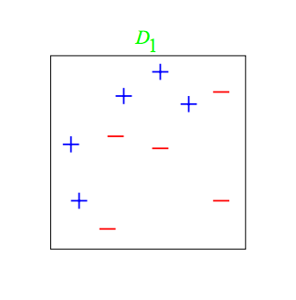

http://webee.technion.ac.il/people/rmeir/BoostingTutorial.pdf

## Round 1: adaboost

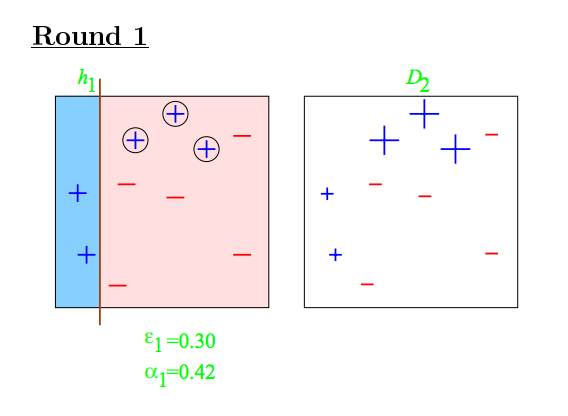

http://webee.technion.ac.il/people/rmeir/BoostingTutorial.pdf

## Round 2 & 3

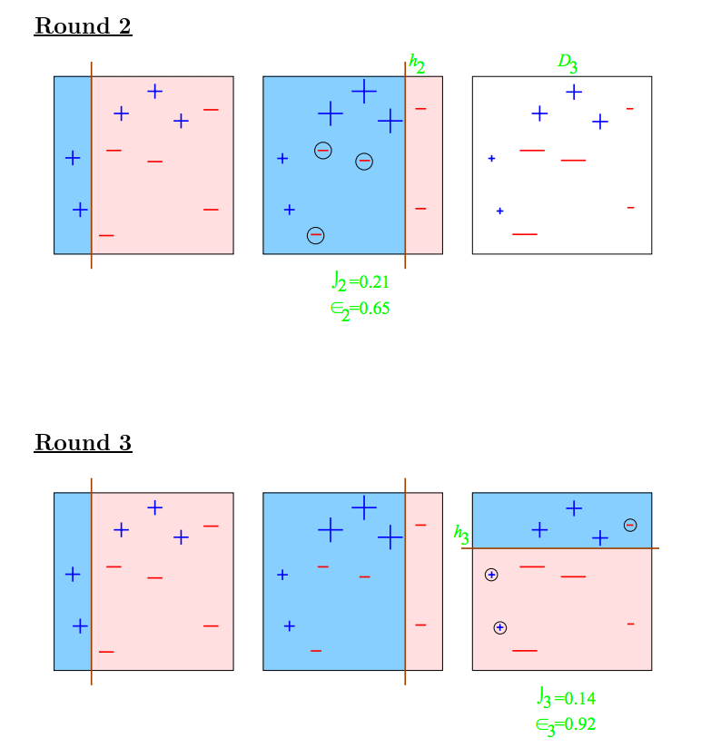

http://webee.technion.ac.il/people/rmeir/BoostingTutorial.pdf

## Completed classifier

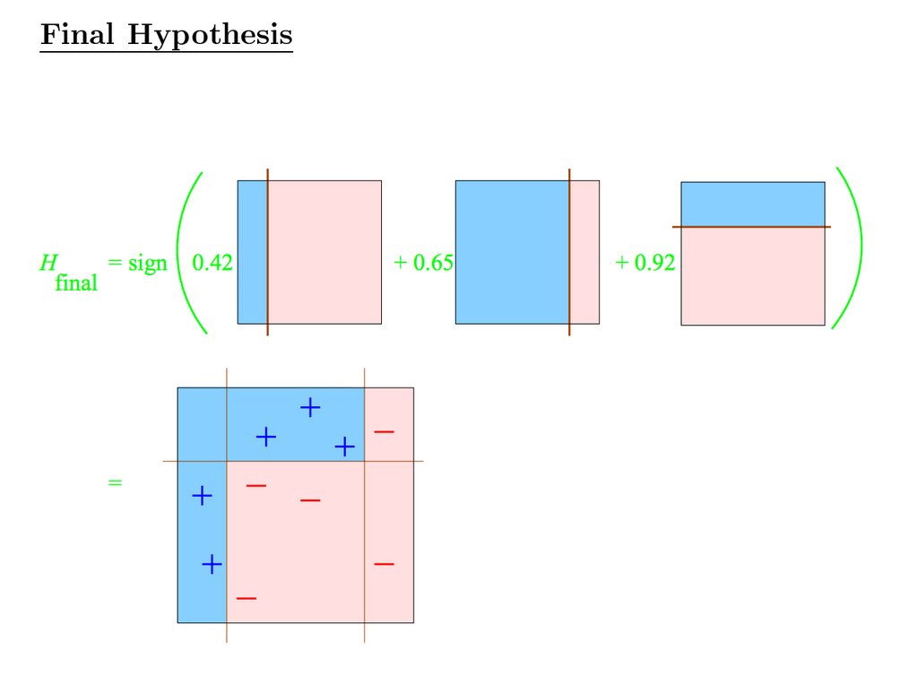

http://webee.technion.ac.il/people/rmeir/BoostingTutorial.pdf

## Boosting in R

- Boosting can be used with any subset of classifiers
- One large subclass is [gradient boosting](http://en.wikipedia.org/wiki/Gradient_boosting)
- R has multiple boosting libraries. Differences include the choice of basic classification functions and combination rules.
- [gbm](http://cran.r-project.org/web/packages/gbm/index.html) - boosting with trees.
- [mboost](http://cran.r-project.org/web/packages/mboost/index.html) - model based boosting
- [ada](http://cran.r-project.org/web/packages/ada/index.html) - statistical boosting based on [additive logistic regression](http://projecteuclid.org/DPubS?service=UI&version=1.0&verb=Display&handle=euclid.aos/1016218223)
- [gamBoost](http://cran.r-project.org/web/packages/GAMBoost/index.html) for boosting generalized additive models
- Most of these are available in the caret package

## Wage example

```r
library(ISLR); data(Wage); library(ggplot2); library(caret);
```

```r
Wage <- subset(Wage,select=-c(logwage))
inTrain <- createDataPartition(y=Wage$wage,
                              p=0.7, list=FALSE)
training <- Wage[inTrain,]; testing <- Wage[-inTrain,]
```

## Fit the model

```r
modFit <- train(wage ~ ., method="gbm",data=training,verbose=FALSE)
print(modFit)
```

```
Stochastic Gradient Boosting

2102 samples
  10 predictors

No pre-processing
Resampling: Bootstrapped (25 reps)

Summary of sample sizes: 2102, 2102, 2102, 2102, 2102, 2102, ...

Resampling results across tuning parameters:

  interaction.depth  n.trees  RMSE  Rsquared  RMSE SD  Rsquared SD
  1                  50       40    0.3       1        0.02
  1                  100      40    0.3       1        0.02
  1                  200      40    0.3       1        0.02
  2                  50       40    0.3       1        0.02
  2                  100      40    0.3       1        0.02
  2                  200      40    0.3       1        0.02
  3                  50       40    0.3       1        0.02
  3                  100      40    0.3       1        0.02
  3                  200      40    0.3       1        0.02

Tuning parameter 'shrinkage' was held constant at a value of 0.1
RMSE was used to select the optimal model using  the smallest value.
The final values used for the model were n.trees = 100, interaction.depth = 2 and shrinkage = 0.1.
```

## Plot the results

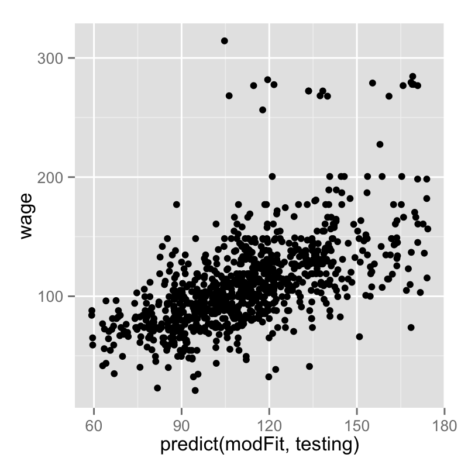

```r
qplot(predict(modFit,testing),wage,data=testing)
```

## Notes and further reading

- A couple of nice tutorials for boosting
- Freund and Shapire - http://www.cc.gatech.edu/~thad/6601-gradAI-fall2013/boosting.pdf
- Ron Meir- http://webee.technion.ac.il/people/rmeir/BoostingTutorial.pdf
- Boosting, random forests, and model ensembling are the most common tools that win Kaggle and other prediction contests.
- http://www.netflixprize.com/assets/GrandPrize2009_BPC_BigChaos.pdf
- https://kaggle2.blob.core.windows.net/wiki-files/327/09ccf652-8c1c-4a3d-b979-ce2369c985e4/Willem%20Mestrom%20-%20Milestone%201%20Description%20V2%202.pdf